# R Notebook

```r
library(beeswarm)
library(naniar)
# install.packages("janitor")
library(janitor)
library(dplyr)
# install.packages("sets")
library(sets)
```

# Make some utility functions

```r
load_file <- function(file_path){
  read.csv(file_path)
}
```

# Business Understanding

# Data Understanding

```r
# Load some of the data
tx_data <- load_file("./../data/COVID-19_cases_TX.csv")
global_mobility_report <- load_file("./../data/Global_Mobility_Report.csv")
cases_plus_census <- load_file("./../data/COVID-19_cases_plus_census.csv")
```

## Verify Data Quality

### Is there missing data?

```r
cols_with_missing <- function(frame){
  colnames(frame)[ apply(frame, 2, anyNA) ]
}
```

```r
tx_missing <- tx_data[cols_with_missing(tx_data)]
global_mobility_report_missing <- global_mobility_report[cols_with_missing(global_mobility_report)]
cases_plus_census_missing <- cases_plus_census[cols_with_missing(cases_plus_census)]
```

```r
class(tx_data)
```

```
[1] "data.frame"
```

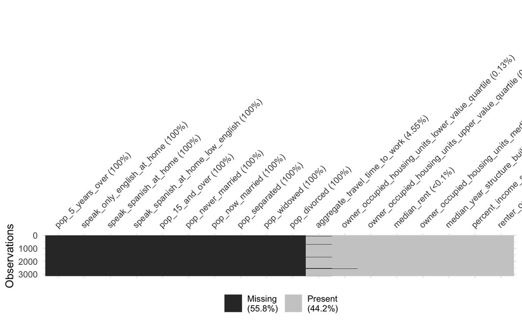

```r
# vis_miss(tx_missing, sort_miss = T)
# vis_miss(global_mobility_report, warn_large_data = F)
vis_miss(cases_plus_census_missing, sort_miss = T)
```

## Clean up DataFrames

First, we noticed that much of our data within the COVID-19_cases_TX file had many rows of data that are statewide and not just for a specific county. Let’s modify the data frame to be texas_county_info and texas_statewide_info.

```r
tx_county_info = filter(tx_data, county_name != "Statewide Unallocated")
tx_statewide_info = filter(tx_data, county_name == "Statewide Unallocated")
```

```r
head(tx_county_info)
```

|  | county_fips_code | county_name | state | state_fips_code | date | confirmed_cases | deaths |
| --- | --- | --- | --- | --- | --- | --- | --- |
| 1 | 48001 | Anderson County | TX | 48 | 2020-01-22 | 0 | 0 |
| 2 | 48001 | Anderson County | TX | 48 | 2020-01-23 | 0 | 0 |
| 3 | 48001 | Anderson County | TX | 48 | 2020-01-24 | 0 | 0 |
| 4 | 48001 | Anderson County | TX | 48 | 2020-01-25 | 0 | 0 |
| 5 | 48001 | Anderson County | TX | 48 | 2020-01-26 | 0 | 0 |
| 6 | 48001 | Anderson County | TX | 48 | 2020-01-27 | 0 | 0 |

```r
head(tx_statewide_info)
```

|  | county_fips_code | county_name | state | state_fips_code | date | confirmed_cases | deaths |
| --- | --- | --- | --- | --- | --- | --- | --- |
| 1 | 0 | Statewide Unallocated | TX | 48 | 2020-01-22 | 0 | 0 |
| 2 | 0 | Statewide Unallocated | TX | 48 | 2020-01-23 | 0 | 0 |
| 3 | 0 | Statewide Unallocated | TX | 48 | 2020-01-24 | 0 | 0 |
| 4 | 0 | Statewide Unallocated | TX | 48 | 2020-01-25 | 0 | 0 |
| 5 | 0 | Statewide Unallocated | TX | 48 | 2020-01-26 | 0 | 0 |
| 6 | 0 | Statewide Unallocated | TX | 48 | 2020-01-27 | 0 | 0 |

### Remove Columns from Data Frames

Remove columns from the dataframes that do not have any data, have the same data repeated (not useful since implicit knowledge)

```r
# Track the columns to see if we are removing any
mobility_cols_orig <- colnames(global_mobility_report)
census_cols_orig <- colnames(cases_plus_census)
tx_county_cols_orig <- colnames(tx_county_info)
tx_statewide_cols_orig <- colnames(tx_statewide_info)

# Remove any columns that do not contain any data
global_mobility_report <- remove_empty(global_mobility_report)
```

```
value for "which" not specified, defaulting to c("rows", "cols")
```

```r
cases_plus_census <- remove_empty(cases_plus_census)
```

```
value for "which" not specified, defaulting to c("rows", "cols")
```

```r
tx_county_info <- remove_empty(tx_county_info)
```

```
value for "which" not specified, defaulting to c("rows", "cols")
```

```r
tx_statewide_info <- remove_empty(tx_statewide_info)
```

```
value for "which" not specified, defaulting to c("rows", "cols")
```

```r
# Remove columns that just have a constant value
global_mobility_report <- remove_constant(global_mobility_report)
cases_plus_census <- remove_constant(cases_plus_census)
tx_county_info <- remove_constant(tx_county_info)
tx_statewide_info <- remove_constant(tx_statewide_info)

mobility_cols_new <- colnames(global_mobility_report)
census_cols_new <- colnames(cases_plus_census)
tx_county_cols_new <- colnames(tx_county_info)
tx_statewide_cols_new <- colnames(tx_statewide_info)
```

```r
# Get sets for columns
print(as.set(mobility_cols_orig) - as.set(mobility_cols_new))
```

```
{}
```

```r
print(as.set(census_cols_orig) - as.set(census_cols_new))
```

```
{"date", "do_date", "pop_15_and_over", "pop_5_years_over", "pop_divorced", "pop_never_married",
 "pop_now_married", "pop_separated", "pop_widowed", "speak_only_english_at_home",
 "speak_spanish_at_home", "speak_spanish_at_home_low_english"}
```

```r
print(as.set(tx_county_cols_orig) - as.set(tx_county_cols_new))
```

```
{"state", "state_fips_code"}
```

```r
print(as.set(tx_county_cols_orig) - as.set(tx_statewide_cols_new))
```

```
{"county_fips_code", "county_name", "state", "state_fips_code"}
```

When removing columns that either do not have data or a constant is repeated throughout the column, the global_mobility_report remains the same; however, the following columns are dropped for the respective dataframes:

- census
  - date, do_date, pop_15_and_over, pop_5_years_over, pop_divorced, pop_never_married, pop_now_married, pop_separated, pop_widowed, speak_only_english_at_home, speak_spanish_at_home,and speak_spanish_at_home_low_english
- tx_county_info
  - state, state_fips_code
- tx_statewide_info
  - county_fips_code, county_name, state, and state_fips_code

```r
head(tx_county_info)
```

|  | county_fips_code | county_name | date | confirmed_cases | deaths |
| --- | --- | --- | --- | --- | --- |
| 1 | 48001 | Anderson County | 2020-01-22 | 0 | 0 |
| 2 | 48001 | Anderson County | 2020-01-23 | 0 | 0 |
| 3 | 48001 | Anderson County | 2020-01-24 | 0 | 0 |
| 4 | 48001 | Anderson County | 2020-01-25 | 0 | 0 |
| 5 | 48001 | Anderson County | 2020-01-26 | 0 | 0 |
| 6 | 48001 | Anderson County | 2020-01-27 | 0 | 0 |

### Are there Duplicates?

```r
mobility_duplicates <- duplicated(global_mobility_report)
census_duplicates <- duplicated(cases_plus_census)
tx_county_duplicates <- duplicated(tx_county_info)
tx_statewide_duplicates <- duplicated(tx_statewide_info)

print(sum(mobility_duplicates, na.rm = TRUE))
```

```
[1] 0
```

```r
print(sum(census_duplicates, na.rm = TRUE))
```

```
[1] 0
```

```r
print(sum(tx_county_duplicates, na.rm = TRUE))
```

```
[1] 0
```

```r
print(sum(tx_statewide_duplicates, na.rm = TRUE))
```

```
[1] 0
```

We can see that there were no duplicate observations in the data. At least none on the basis that the data was the exact same.

```r
unique(mobility_duplicates)
```

```
[1] FALSE
```